# STAT 420 Final Project

Danilo Canivel, Joel Zou, Danny Breyfogle

08/03/2019

# Introduction

This study will be conducted by the following students of Stat420 Summer 2019:

- Danilo Canivel (canivel2)
- Joel Zou (joelzou2)
- Danny Breyfogle (dwb4)

## Let’s call a Taxi… Maybe not.

## Dataset

For this project we will be predicting the fare amount (inclusive of tolls) for a taxi ride in New York City given the pickup and dropoff locations.

This dataset has 6 features:

- `pickup_datetime` (datetime)
- `pickup_longitude` (numeric)
- `pickup_latitude` (numeric)
- `dropoff_longitude` (numeric)
- `dropoff_latitude` (numeric)
- `passenger counts` (numeric)

We will be predicting the numeric response `fare_amount`, fitting on a training set, and predicting on a test set.

There are about 55 million observations in the training set. This is a very large dataset, so we may need to use a subset to meet computing requirements. In order to satisfy the project requirement of at least one categorical predictor, we can transform the `pickup_datetime` feature into categorical variables that would potentially be helpful in determining the fare amount, some examples would be day of the week, morning, afternoon, evening, etc.

We are going to set a preliminary objective of trying to reach a $RMSE < 2$ but a $RMSE < 2.88$ can be considered acceptable.

The dataset can be found at: https://www.kaggle.com/c/new-york-city-taxi-fare-prediction/data

## Read Data

```r
nrows = 500000
fdata = read.csv("../input/train.csv", stringsAsFactors=FALSE, nrows=nrows)
head(fdata)
```

```
##                             key fare_amount         pickup_datetime
## 1   2009-06-15 17:26:21.0000001         4.5 2009-06-15 17:26:21 UTC
## 2   2010-01-05 16:52:16.0000002        16.9 2010-01-05 16:52:16 UTC
## 3  2011-08-18 00:35:00.00000049         5.7 2011-08-18 00:35:00 UTC
## 4   2012-04-21 04:30:42.0000001         7.7 2012-04-21 04:30:42 UTC
## 5 2010-03-09 07:51:00.000000135         5.3 2010-03-09 07:51:00 UTC
## 6   2011-01-06 09:50:45.0000002        12.1 2011-01-06 09:50:45 UTC
##   pickup_longitude pickup_latitude dropoff_longitude dropoff_latitude
## 1        -73.84431        40.72132         -73.84161         40.71228
## 2        -74.01605        40.71130         -73.97927         40.78200
## 3        -73.98274        40.76127         -73.99124         40.75056
## 4        -73.98713        40.73314         -73.99157         40.75809
## 5        -73.96810        40.76801         -73.95665         40.78376
## 6        -74.00096        40.73163         -73.97289         40.75823
##   passenger_count
## 1               1
## 2               1
## 3               2
## 4               1
## 5               1
## 6               1
```

# Methods

```r
library(lubridate)
library(ggplot2)
library(cluster)
library(tidyverse)
library(caret)
library(magrittr)
library(Matrix)
library(faraway)
```

## Outlier Removal

In the dataset, the continuous variables `fare_amount`, `pickup_longitude`, `pickup_latitude`, `dropoff_longitude`, `dropoff_latitude` can be assumed to be normally distributed. Since linear regression model coefficients are sensitive to outliers in the training data, we will use the boxplot rule to remove observations that have values greater than 1.5 IQR away from the median in each of these variables, which should help make our model generalize to unseen data that would follow a similar normal distribution.

```r
# remove na obs
fdata = na.omit(fdata)
```

** detecting outliers **

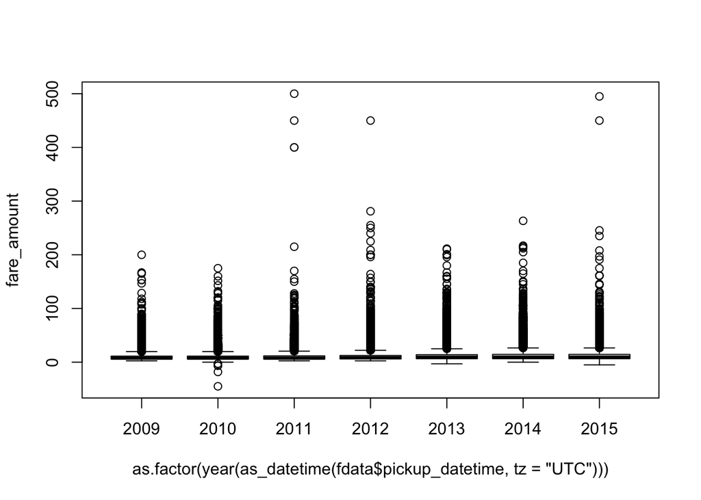

```r
boxplot(fare_amount ~ as.factor(year(as_datetime(fdata$pickup_datetime, tz="UTC"))), fdata)
```

```r
fdata = fdata[fdata$pickup_longitude < median(fdata$pickup_longitude) + 1.5 * IQR( fdata$pickup_longitude) &
              fdata$pickup_longitude > median(fdata$pickup_longitude - 1.5 * IQR(fdata$pickup_longitude)) &
              fdata$pickup_latitude < median(fdata$pickup_latitude) + 1.5 * IQR(fdata$pickup_latitude) &
              fdata$pickup_latitude > median(fdata$pickup_latitude) - 1.5 * IQR(fdata$pickup_latitude),]
  print(dim(fdata))
```

```
## [1] 445706      8
```

```r
  # Outlier Dropoff locations
  fdata = fdata[fdata$dropoff_longitude < median(fdata$dropoff_longitude) + 1.5 * IQR(fdata$dropoff_longitude) &
              fdata$dropoff_longitude > median(fdata$dropoff_longitude - 1.5 * IQR(fdata$dropoff_longitude)) &
              fdata$dropoff_latitude < median(fdata$dropoff_latitude) + 1.5 * IQR(fdata$dropoff_latitude) &
              fdata$dropoff_latitude > median(fdata$dropoff_latitude) - 1.5 * IQR(fdata$dropoff_latitude),]
  print(dim(fdata))
```

```
## [1] 396024      8
```

```r
  # Outlier Fare Amount
fdata = fdata[fdata$fare_amount < median(fdata$fare_amount) + 1.5 * IQR(fdata$fare_amount),]
```

** not as many outliers afterwards **

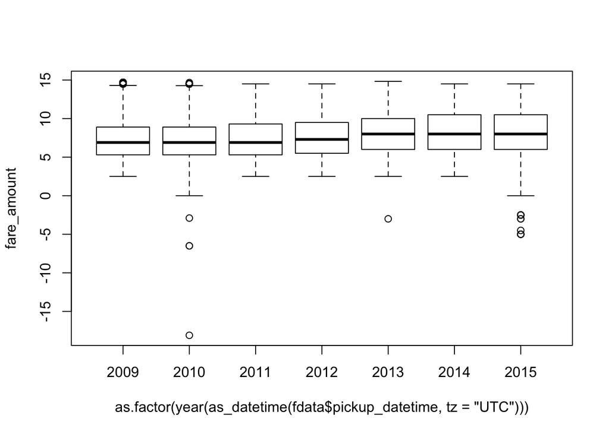

```r
boxplot(fare_amount ~ as.factor(year(as_datetime(fdata$pickup_datetime, tz="UTC"))), fdata)
```

## Feature Engineering

Several features have been created in this step: - First, if we are processing for training, we are going to remove several outliers related to fare amount, location and passenger count. - Next, we factorize some of the features to work as categories - Time, for example, is factored into 6 different categories - The locations are converted to radius - We decide to add a few locations where taxis usually take or drop passengers in NYC - We compute haversine distance and Bearing distances

```r
earth_radius = 6371 #in kms

sphere_dist = function(pickup_lat, pickup_lon, dropoff_lat, dropoff_lon)
{
    #Compute distances along lat, lon dimensions
    dlat = dropoff_lat - pickup_lat
    dlon = dropoff_lon - pickup_lon

    #Compute  distance
    a = sin(dlat/2.0)**2 + cos(pickup_lat) * cos(dropoff_lat) * sin(dlon/2.0)**2

    return (2 * earth_radius * asin(sqrt(a)))

}

features_eng = function(data, istrain=TRUE){

  if(istrain == TRUE){
    #data = data[complete.cases(data),]
    # Remove Negative Fare and No Passenger and some places that does not exist
    data = data[(data$fare_amount > 0 & data$fare_amount <= 500),]
    data = data[(data$pickup_longitude > -80 && data$pickup_longitude < -70),]
    data = data[(data$pickup_latitude > 35 && data$pickup_latitude < 45),]
    data = data[(data$dropoff_longitude > -80 && data$dropoff_longitude < -70),]
    data = data[(data$dropoff_latitude > 35 && data$dropoff_latitude < 45),]
    #only if passengers are between 1 and 9
    data = data[(data$passenger_count > 0 && data$passenger_count < 10),]
  }

  # Convert to datetime obj
  data$pickup_datetime = as_datetime(data$pickup_datetime, tz="UTC")

  # factorization
  data$year = as.factor(year(data$pickup_datetime))
  data$month = as.factor(month(data$pickup_datetime))
  data$day = as.factor(day(data$pickup_datetime))
  data$weekday = as.factor(weekdays(data$pickup_datetime))

  #factor time of the day
  hour = hour(data$pickup_datetime)
  data$time = as.factor(ifelse(hour < 7, "Overnight",
                               ifelse(hour < 11, "Morning",
                                      ifelse(hour < 16, "Noon",
                                             ifelse(hour < 20, "Evening",
                                                    ifelse(hour < 23, "night", "overnight")
                        )))))
  # convert to radius position
  data$pickup_latitude = (data$pickup_latitude * pi)/180
  data$dropoff_latitude = (data$dropoff_latitude * pi)/180
  data$dropoff_longitude = (data$dropoff_longitude * pi)/180
  data$pickup_longitude = (data$pickup_longitude * pi)/180
  data$dropoff_longitude = ifelse(is.na(data$dropoff_longitude) == TRUE, 0,data$dropoff_longitude)
  data$pickup_longitude = ifelse(is.na(data$pickup_longitude) == TRUE, 0,data$pickup_longitude)
  data$pickup_latitude = ifelse(is.na(data$pickup_latitude) == TRUE, 0,data$pickup_latitude)
  data$dropoff_latitude = ifelse(is.na(data$dropoff_latitude) == TRUE, 0,data$dropoff_latitude)

  # compare locations
  data$dlat = data$dropoff_latitude - data$pickup_latitude
  data$dlon = data$dropoff_longitude - data$pickup_longitude

  #Compute haversine distance

  data$hav = sin(data$dlat/2.0)**2 + cos(data$pickup_latitude) * cos(data$dropoff_latitude) * sin(data$dlon/2.0)**2
  data$haversine = round(x = 2 * earth_radius * asin(sqrt(data$hav)), digits = 4)
  print(dim(data))

  #Compute Bearing distance
  data$dlon = data$pickup_longitude - data$dropoff_longitude
  data$bearing = atan2(sin(data$dlon * cos(data$dropoff_latitude)), cos(data$pickup_latitude) * sin(data$dropoff_latitude) - sin(data$pickup_latitude) * cos(data$dropoff_latitude) * cos(data$dlon))

  #Some point of interest where people most use taxis in NYC
  jfk_coord_lat = (40.639722 * pi)/180
  jfk_coord_long = (-73.778889 * pi)/180
  ewr_coord_lat = (40.6925 * pi)/180
  ewr_coord_long = (-74.168611 * pi)/180
  lga_coord_lat = (40.77725 * pi)/180
  lga_coord_long = (-73.872611 * pi)/180
  liberty_statue_lat = (40.6892 * pi)/180
  liberty_statue_long = (-74.0445 * pi)/180
  nyc_lat = (40.7141667 * pi)/180
  nyc_long = (-74.0063889 * pi)/180

  #calculate distances radius for the POI
  data$JFK_dist = sphere_dist(data$pickup_latitude, data$pickup_longitude, jfk_coord_lat, jfk_coord_long) + sphere_dist(jfk_coord_lat, jfk_coord_long, data$dropoff_latitude, data$dropoff_longitude)
  data$EWR_dist = sphere_dist(data$pickup_latitude, data$pickup_longitude, ewr_coord_lat, ewr_coord_long) +  sphere_dist(ewr_coord_lat, ewr_coord_long, data$dropoff_latitude, data$dropoff_longitude)
  data$lga_dist = sphere_dist(data$pickup_latitude, data$pickup_longitude, lga_coord_lat, lga_coord_long) + sphere_dist(lga_coord_lat, lga_coord_long, data$dropoff_latitude, data$dropoff_longitude)
  data$sol_dist = sphere_dist(data$pickup_latitude, data$pickup_longitude, liberty_statue_lat, liberty_statue_long) + sphere_dist(liberty_statue_lat, liberty_statue_long, data$dropoff_latitude, data$dropoff_longitude)
  data$nyc_dist = sphere_dist(data$pickup_latitude, data$pickup_longitude, nyc_lat, nyc_long) + sphere_dist(nyc_lat, nyc_long, data$dropoff_latitude, data$dropoff_longitude)

  #remove some columns
  drops <- c("key","pickup_datetime")
  data = data[, !(names(data) %in% drops)]
  print(dim(data))
  return (data)

}
```

```r
fdata = features_eng(data = fdata)
```

```
## [1] 361913     17
## [1] 361913     21
```

## Calculate anova test for each dummy variable

```r
dummy_anova = function(pred, resp) {
  m0 = lm(resp ~ 1)
  m1 = lm(resp ~ pred)
  anova(m0, m1)[["Pr(>F)"]][2]
}
```

```r
cols = c("year", "month", "day", "weekday", "time")
pvals = rep(0, length(cols))
for (i in 1:length(cols)) pvals[i] = dummy_anova(fdata[[cols[i]]], fdata$fare_amount)
df = data.frame(dummyvar=cols, pvals=pvals)
knitr::kable(df)
```

| dummyvar | pvals |
| --- | --- |
| year | 0.0000000 |
| month | 0.0000000 |
| day | 0.0003515 |
| weekday | 0.0000000 |
| time | 0.0000000 |

## Lets split the data for training and test

```r
inds = sample.int(nrow(fdata), size=nrow(fdata) * 0.9)
train = fdata[inds,]
test = fdata[-inds,]
dim(train)
```

```
## [1] 325721     21
```

```r
dim(test)
```

```
## [1] 36192    21
```

```r
head(train)
```

```
##        fare_amount pickup_longitude pickup_latitude dropoff_longitude
## 66408          6.5        -1.291671       0.7111068         -1.291416
## 38675          8.1        -1.291629       0.7112518         -1.291329
## 465304         4.1        -1.290849       0.7115072         -1.290989
## 80473          4.5        -1.291536       0.7109337         -1.291454
## 251696         8.0        -1.290752       0.7118606         -1.290576
## 308480         9.3        -1.290845       0.7115183         -1.291276
##        dropoff_latitude passenger_count year month day   weekday    time
## 66408         0.7115289               2 2012     8  28   Tuesday   night
## 38675         0.7112186               1 2011     1  25   Tuesday Morning
## 465304        0.7113092               1 2012     7  14  Saturday Morning
## 80473         0.7108533               1 2014    12  13  Saturday Morning
## 251696        0.7116841               1 2014     1  29 Wednesday Evening
## 308480        0.7115438               1 2012     7  18 Wednesday Morning
##                 dlat          dlon          hav haversine    bearing
## 66408   4.221602e-04 -2.556384e-04 5.392957e-08    2.9590 -0.4299852
## 38675  -3.317871e-05 -2.998999e-04 1.317915e-08    1.4628 -1.7157121
## 465304 -1.979727e-04  1.403943e-04 1.262538e-08    1.4317  2.6486241
## 80473  -8.045968e-05 -8.264134e-05 2.598878e-09    0.6496 -2.4801808
## 251696 -1.764528e-04 -1.762957e-04 1.223893e-08    1.4096 -2.4938670
## 308480  2.544690e-05  4.308694e-04 2.678382e-08    2.0853  1.4928328
##        JFK_dist EWR_dist lga_dist sol_dist  nyc_dist
## 66408  45.40327 31.73994 22.12094 16.54478  9.306539
## 38675  44.20794 31.81083 21.66007 15.97904  8.444156
## 465304 41.25328 37.65025 15.89596 20.88065 12.553903
## 80473  42.06553 30.15256 23.36554 12.29500  4.129496
## 251696 42.69722 41.90587 13.04385 26.06524 17.828629
## 308480 43.30575 37.08546 16.93120 21.35857 13.364776
```

## Setting the RMSE and LOORMSE functions

```r
calc_rmse = function(model) {
  sqrt(mean((resid(model) / (1 - hatvalues(model))) ^ 2))
}

calc_rmse2 = function(model, data){
  sqrt(sum((data$fare_amount - predict(model, newdata=data))^2) / nrow(data))
}
```

## Multiple Linear Regression

** Lets start by doing a simple baseline model and checking the results **

```r
m_additive = lm(fare_amount ~ dropoff_longitude + dropoff_latitude + pickup_latitude + pickup_longitude + passenger_count + year + month + day + weekday + time + dlat + dlon + haversine + bearing, train)
```

** Looks like correlation is out of control**

```r
vif(m_additive)
```

```
## dropoff_longitude  dropoff_latitude   pickup_latitude  pickup_longitude
##      2.957850e+00      2.288685e+00      2.447571e+00      3.141281e+00
##   passenger_count          year2010          year2011          year2012
##      1.003963e+00      1.655559e+00      1.677687e+00      1.669779e+00
##          year2013          year2014          year2015            month2
##      1.629065e+00      1.599018e+00      1.374428e+00      1.784399e+00
##            month3            month4            month5            month6
##      1.834116e+00      1.820471e+00      1.812307e+00      1.797959e+00
##            month7            month8            month9           month10
##      1.713955e+00      1.673063e+00      1.689595e+00      1.744967e+00
##           month11           month12              day2              day3
##      1.698641e+00      1.709126e+00      1.951737e+00      1.966660e+00
##              day4              day5              day6              day7
##      1.962408e+00      1.975018e+00      1.995112e+00      2.015502e+00
##              day8              day9             day10             day11
##      2.027012e+00      2.041339e+00      2.016101e+00      2.029593e+00
##             day12             day13             day14             day15
##      2.043573e+00      2.039201e+00      2.020868e+00      2.019923e+00
##             day16             day17             day18             day19
##      2.033167e+00      2.021562e+00      2.030691e+00      2.020123e+00
##             day20             day21             day22             day23
##      2.021898e+00      2.017521e+00      2.013819e+00      2.006211e+00
##             day24             day25             day26             day27
##      1.989568e+00      1.932123e+00      1.935185e+00      1.932952e+00
##             day28             day29             day30             day31
##      1.958281e+00      1.922899e+00      1.889444e+00      1.586019e+00
##     weekdayMonday   weekdaySaturday     weekdaySunday   weekdayThursday
##      1.611722e+00      1.704786e+00      1.614610e+00      1.683690e+00
##    weekdayTuesday  weekdayWednesday       timeMorning         timenight
##      1.659920e+00      1.669324e+00      1.498298e+00      1.488746e+00
##          timeNoon     timeovernight     timeOvernight              dlat
##      1.603965e+00      1.165224e+00      1.438033e+00      6.835531e-08
##              dlon         haversine           bearing
##      4.472865e-08      6.186035e+07      6.413065e+07
```

```r
calc_rmse(m_additive)
```

```
## [1] 1.661895
```

```r
calc_rmse2(m_additive, test)
```

```
## [1] 1.675432
```

** Let’s try to find better features from the additive model to fix the error: prediction from a rank-deficient fit may be misleading **

```r
n = length(resid(m_additive))
m_additive_bic = step(m_additive, direction = "both", k = log(n))
```

```
## Start:  AIC=331609.1
## fare_amount ~ dropoff_longitude + dropoff_latitude + pickup_latitude +
##     pickup_longitude + passenger_count + year + month + day +
##     weekday + time + dlat + dlon + haversine + bearing
##
##
## Step:  AIC=331609.1
## fare_amount ~ dropoff_longitude + dropoff_latitude + pickup_latitude +
##     pickup_longitude + passenger_count + year + month + day +
##     weekday + time + dlat + haversine + bearing
##
##
## Step:  AIC=331609.1
## fare_amount ~ dropoff_longitude + dropoff_latitude + pickup_latitude +
##     pickup_longitude + passenger_count + year + month + day +
##     weekday + time + haversine + bearing
##
##                     Df Sum of Sq     RSS    AIC
## - day               30       380  899616 331366
## <none>                            899237 331609
## - pickup_latitude    1       282  899519 331699
## - passenger_count    1       593  899830 331811
## - dropoff_latitude   1      3901  903138 333006
## - pickup_longitude   1      5048  904284 333420
## - month             11      7138  906374 334045
## - weekday            6      7472  906709 334228
## - dropoff_longitude  1      8020  907257 334489
## - bearing            1     18427  917663 338203
## - time               5     31662  930899 342817
## - year               6    100628  999865 366083
## - haversine          1   1530780 2430017 655398
##
## Step:  AIC=331365.8
## fare_amount ~ dropoff_longitude + dropoff_latitude + pickup_latitude +
##     pickup_longitude + passenger_count + year + month + weekday +
##     time + haversine + bearing
##
##                     Df Sum of Sq     RSS    AIC
## <none>                            899616 331366
## - pickup_latitude    1       284  899901 331456
## - passenger_count    1       591  900207 331567
## + day               30       380  899237 331609
## - dropoff_latitude   1      3909  903525 332765
## - pickup_longitude   1      5044  904660 333174
## - month             11      7133  906749 333799
## - weekday            6      7459  907075 333979
## - dropoff_longitude  1      8020  907636 334244
## - bearing            1     18439  918055 337962
## - time               5     31647  931264 342564
## - year               6    100577 1000193 365810
## - haversine          1   1530839 2430455 655076
```

```r
vif(m_additive_bic)
```

```
## dropoff_longitude  dropoff_latitude   pickup_latitude  pickup_longitude
##          2.957609          2.288428          2.447340          3.140935
##   passenger_count          year2010          year2011          year2012
##          1.003882          1.655185          1.677324          1.669415
##          year2013          year2014          year2015            month2
##          1.628760          1.598590          1.374217          1.772135
##            month3            month4            month5            month6
##          1.833424          1.814276          1.810610          1.791537
##            month7            month8            month9           month10
##          1.713257          1.672269          1.684615          1.744187
##           month11           month12     weekdayMonday   weekdaySaturday
##          1.692959          1.706603          1.609828          1.701115
##     weekdaySunday   weekdayThursday    weekdayTuesday  weekdayWednesday
##          1.612864          1.680302          1.657480          1.667701
##       timeMorning         timenight          timeNoon     timeovernight
##          1.498053          1.488624          1.603766          1.165082
##     timeOvernight         haversine           bearing
##          1.437816          1.080492          1.997883
```

** correlation is under control**

```r
calc_rmse(m_additive_bic)
```

```
## [1] 1.662092
```

```r
calc_rmse2(m_additive_bic, test)
```

```
## [1] 1.675649
```

** lets check the statistics and the p-value for both additive models**

```r
summary(m_additive)
```

```
##
## Call:
## lm(formula = fare_amount ~ dropoff_longitude + dropoff_latitude +
##     pickup_latitude + pickup_longitude + passenger_count + year +
##     month + day + weekday + time + dlat + dlon + haversine +
##     bearing, data = train)
##
## Residuals:
##      Min       1Q   Median       3Q      Max
## -18.5645  -1.0719  -0.2509   0.8048  11.7280
##
## Coefficients: (2 not defined because of singularities)
##                     Estimate Std. Error t value Pr(>|t|)
## (Intercept)        3.082e+01  3.080e+01   1.000 0.317136
## dropoff_longitude -1.002e+03  1.859e+01 -53.893  < 2e-16 ***
## dropoff_latitude  -4.856e+02  1.292e+01 -37.585  < 2e-16 ***
## pickup_latitude    1.369e+02  1.355e+01  10.106  < 2e-16 ***
## pickup_longitude   8.311e+02  1.944e+01  42.754  < 2e-16 ***
## passenger_count    3.290e-02  2.244e-03  14.659  < 2e-16 ***
## year2010          -4.761e-02  1.029e-02  -4.627 3.71e-06 ***
## year2011           5.845e-02  1.018e-02   5.745 9.22e-09 ***
## year2012           3.866e-01  1.022e-02  37.836  < 2e-16 ***
## year2013           1.138e+00  1.044e-02 108.947  < 2e-16 ***
## year2014           1.253e+00  1.063e-02 117.914  < 2e-16 ***
## year2015           1.406e+00  1.386e-02 101.453  < 2e-16 ***
## month2             8.431e-02  1.383e-02   6.096 1.09e-09 ***
## month3             9.761e-02  1.349e-02   7.235 4.66e-13 ***
## month4             1.515e-01  1.359e-02  11.144  < 2e-16 ***
## month5             2.040e-01  1.360e-02  15.007  < 2e-16 ***
## month6             2.245e-01  1.371e-02  16.368  < 2e-16 ***
## month7             1.163e-01  1.430e-02   8.137 4.07e-16 ***
## month8             9.058e-02  1.456e-02   6.222 4.91e-10 ***
## month9             3.704e-01  1.449e-02  25.563  < 2e-16 ***
## month10            4.121e-01  1.412e-02  29.193  < 2e-16 ***
## month11            4.327e-01  1.444e-02  29.970  < 2e-16 ***
## month12            4.648e-01  1.434e-02  32.411  < 2e-16 ***
## day2              -4.518e-02  2.334e-02  -1.935 0.052930 .
## day3              -3.276e-02  2.325e-02  -1.409 0.158780
## day4               1.306e-02  2.328e-02   0.561 0.574737
## day5               1.841e-02  2.320e-02   0.793 0.427611
```

[output cut: 32 more lines]

```
## timeMorning       -7.230e-02  9.283e-03  -7.789 6.78e-15 ***
## timenight         -4.064e-01  9.400e-03 -43.238  < 2e-16 ***
## timeNoon           2.086e-01  8.505e-03  24.528  < 2e-16 ***
## timeovernight     -5.326e-01  1.492e-02 -35.700  < 2e-16 ***
## timeOvernight     -7.467e-01  1.040e-02 -71.807  < 2e-16 ***
## dlat                      NA         NA      NA       NA
## dlon                      NA         NA      NA       NA
## haversine          1.830e+00  2.457e-03 744.558  < 2e-16 ***
## bearing           -1.863e-01  2.281e-03 -81.689  < 2e-16 ***
## ---
## Signif. codes:  0 '***' 0.001 '**' 0.01 '*' 0.05 '.' 0.1 ' ' 1
##
## Residual standard error: 1.662 on 325655 degrees of freedom
## Multiple R-squared:  0.6427, Adjusted R-squared:  0.6426
## F-statistic:  9011 on 65 and 325655 DF,  p-value: < 2.2e-16
```

```r
summary(m_additive_bic)
```

```
##
## Call:
## lm(formula = fare_amount ~ dropoff_longitude + dropoff_latitude +
##     pickup_latitude + pickup_longitude + passenger_count + year +
##     month + weekday + time + haversine + bearing, data = train)
##
## Residuals:
##      Min       1Q   Median       3Q      Max
## -18.5623  -1.0722  -0.2511   0.8058  11.7349
##
## Coefficients:
##                     Estimate Std. Error t value Pr(>|t|)
## (Intercept)        3.040e+01  3.081e+01   0.987    0.324
## dropoff_longitude -1.002e+03  1.860e+01 -53.884  < 2e-16 ***
## dropoff_latitude  -4.861e+02  1.292e+01 -37.617  < 2e-16 ***
## pickup_latitude    1.375e+02  1.355e+01  10.147  < 2e-16 ***
## pickup_longitude   8.307e+02  1.944e+01  42.733  < 2e-16 ***
## passenger_count    3.283e-02  2.244e-03  14.627  < 2e-16 ***
## year2010          -4.687e-02  1.029e-02  -4.555 5.24e-06 ***
## year2011           5.814e-02  1.018e-02   5.714 1.11e-08 ***
## year2012           3.862e-01  1.022e-02  37.798  < 2e-16 ***
## year2013           1.138e+00  1.044e-02 108.936  < 2e-16 ***
## year2014           1.252e+00  1.063e-02 117.829  < 2e-16 ***
## year2015           1.406e+00  1.386e-02 101.437  < 2e-16 ***
## month2             8.198e-02  1.378e-02   5.947 2.73e-09 ***
## month3             9.623e-02  1.349e-02   7.133 9.84e-13 ***
## month4             1.499e-01  1.357e-02  11.043  < 2e-16 ***
## month5             2.018e-01  1.359e-02  14.849  < 2e-16 ***
## month6             2.224e-01  1.369e-02  16.244  < 2e-16 ***
## month7             1.157e-01  1.430e-02   8.090 5.98e-16 ***
## month8             8.890e-02  1.456e-02   6.107 1.02e-09 ***
## month9             3.694e-01  1.447e-02  25.529  < 2e-16 ***
## month10            4.101e-01  1.412e-02  29.056  < 2e-16 ***
## month11            4.311e-01  1.442e-02  29.903  < 2e-16 ***
## month12            4.634e-01  1.433e-02  32.333  < 2e-16 ***
## weekdayMonday     -2.996e-01  1.100e-02 -27.243  < 2e-16 ***
## weekdaySaturday   -1.990e-01  1.056e-02 -18.848  < 2e-16 ***
## weekdaySunday     -4.136e-01  1.117e-02 -37.034  < 2e-16 ***
## weekdayThursday    1.544e-02  1.057e-02   1.460    0.144
## weekdayTuesday    -7.257e-02  1.072e-02  -6.768 1.31e-11 ***
## weekdayWednesday   3.820e-03  1.065e-02   0.359    0.720
## timeMorning       -7.193e-02  9.284e-03  -7.748 9.37e-15 ***
## timenight         -4.063e-01  9.401e-03 -43.218  < 2e-16 ***
## timeNoon           2.086e-01  8.506e-03  24.523  < 2e-16 ***
## timeovernight     -5.319e-01  1.492e-02 -35.652  < 2e-16 ***
## timeOvernight     -7.465e-01  1.040e-02 -71.781  < 2e-16 ***
## haversine          1.830e+00  2.458e-03 744.449  < 2e-16 ***
## bearing           -1.864e-01  2.281e-03 -81.703  < 2e-16 ***
## ---
## Signif. codes:  0 '***' 0.001 '**' 0.01 '*' 0.05 '.' 0.1 ' ' 1
##
## Residual standard error: 1.662 on 325685 degrees of freedom
## Multiple R-squared:  0.6425, Adjusted R-squared:  0.6425
## F-statistic: 1.673e+04 on 35 and 325685 DF,  p-value: < 2.2e-16
```

```r
anova(m_additive_bic, m_additive)
```

```
## Analysis of Variance Table
##
## Model 1: fare_amount ~ dropoff_longitude + dropoff_latitude + pickup_latitude +
##     pickup_longitude + passenger_count + year + month + weekday +
##     time + haversine + bearing
## Model 2: fare_amount ~ dropoff_longitude + dropoff_latitude + pickup_latitude +
##     pickup_longitude + passenger_count + year + month + day +
##     weekday + time + dlat + dlon + haversine + bearing
##   Res.Df    RSS Df Sum of Sq      F    Pr(>F)
## 1 325685 899616
## 2 325655 899237 30    379.55 4.5818 1.078e-15 ***
## ---
## Signif. codes:  0 '***' 0.001 '**' 0.01 '*' 0.05 '.' 0.1 ' ' 1
```

** Test log transform on response **

```r
m_additive_log = lm(log(fare_amount) ~ dropoff_longitude + dropoff_latitude + pickup_latitude +
    pickup_longitude + passenger_count + year + month + weekday +
    time + haversine + bearing, train)
```

```r
# test rmse
sqrt(sum((test$fare_amount - exp(predict(m_additive_log, test)))^2) / nrow(test))
```

```
## [1] 1.886351
```

** It appears that log transform hurts the performance of the model on the test set so we will not consider this model**

- Try interaction of the variables selected *

```r
m_int = lm(fare_amount ~ (dropoff_longitude + dropoff_latitude + pickup_latitude +
    pickup_longitude + passenger_count + year + month + weekday +
    time + haversine + bearing)^2, train)
```

```r
calc_rmse(m_int)
```

```
## [1] 1.563796
```

```r
calc_rmse2(m_int, test)
```

```
## [1] 1.575824
```

```r
anova(m_additive_bic, m_int)
```

```
## Analysis of Variance Table
##
## Model 1: fare_amount ~ dropoff_longitude + dropoff_latitude + pickup_latitude +
##     pickup_longitude + passenger_count + year + month + weekday +
##     time + haversine + bearing
## Model 2: fare_amount ~ (dropoff_longitude + dropoff_latitude + pickup_latitude +
##     pickup_longitude + passenger_count + year + month + weekday +
##     time + haversine + bearing)^2
##   Res.Df    RSS  Df Sum of Sq      F    Pr(>F)
## 1 325685 899616
## 2 325195 793813 490    105803 88.456 < 2.2e-16 ***
## ---
## Signif. codes:  0 '***' 0.001 '**' 0.01 '*' 0.05 '.' 0.1 ' ' 1
```

** we clear see that the results are better, but probably there is some overfit since we are interatcting several factorized features, more data will proably be necessary to train such larger model **

** comparing both the aditive bic and the interactive, the interactive is much better so we assume it is the better model **